# CTSBS Age-Mixing

Roxanne Beauclair

25 May 2017

**Research questions:**

1. Describe the age-mixing pattern in the CTSBS population. Does the age-mixing pattern of HIV positive participants differ from HIV negative participants?
2. At the individual-level are large ranges in partner ages (bridgewidths) associated with HIV status of a participant?

Before conducting imputations, I excluded participants who said their sexual preferences were for “both” genders or the same gender (n = 76). I further excluded people who did not identify as black or coloured (n = 7) and people who did not report partners in the previous year (n = 170). Participants who had missing observations on those characteristics were left in the dataset. This left 1074 relationships reported by 647 participants. Of the 647 participants, 185 reported more than one relationship in the previous year. I imputed 50 datasets using the random forest method for continuous and nominal categorical variables and the “polr” method for our ordinal variables.

### **AGE-MIXING PATTERN**

Here I used linear mixed effects models that were stratified by sex and contained a random intercept for the participant. For the plots, I randomly selected an imputed dataset to visualize the pattern in that population. Heteroskedastic variance is now taken into account in the models that produced these predictions.

###### **Figure 1. Age mixing pattern for randomly selected imputed dataset. The top row represents the male and female age mixing patterns HIV negative study population, while the bottom row is for only those with HIV**

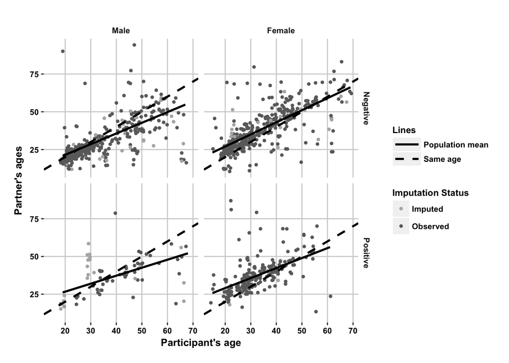

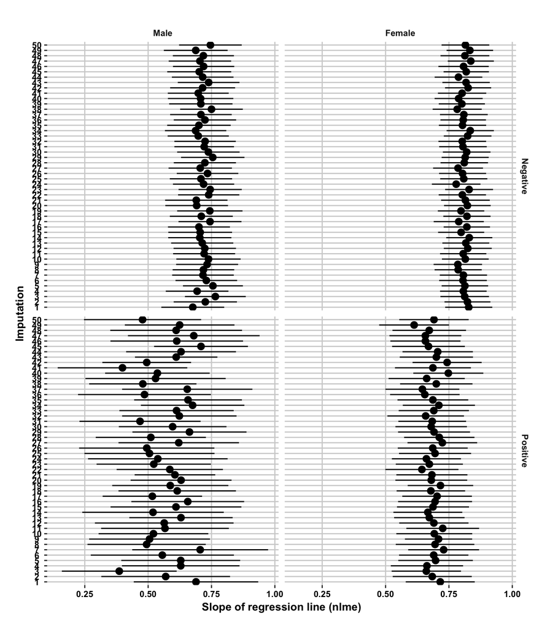

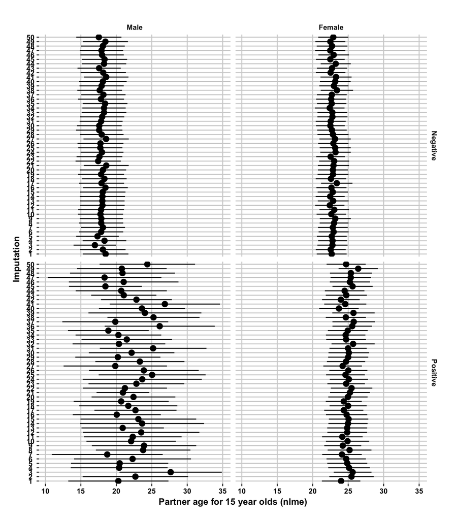

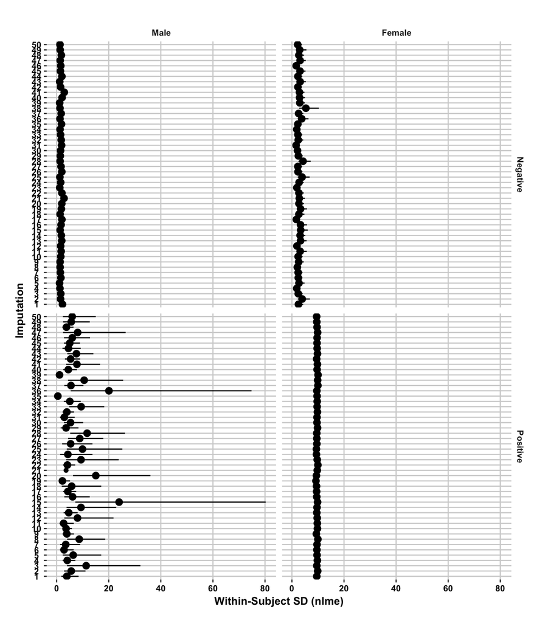

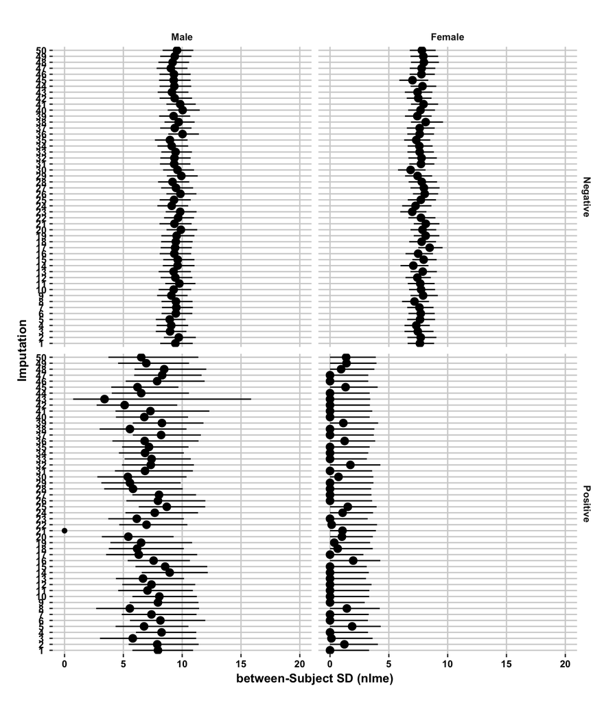

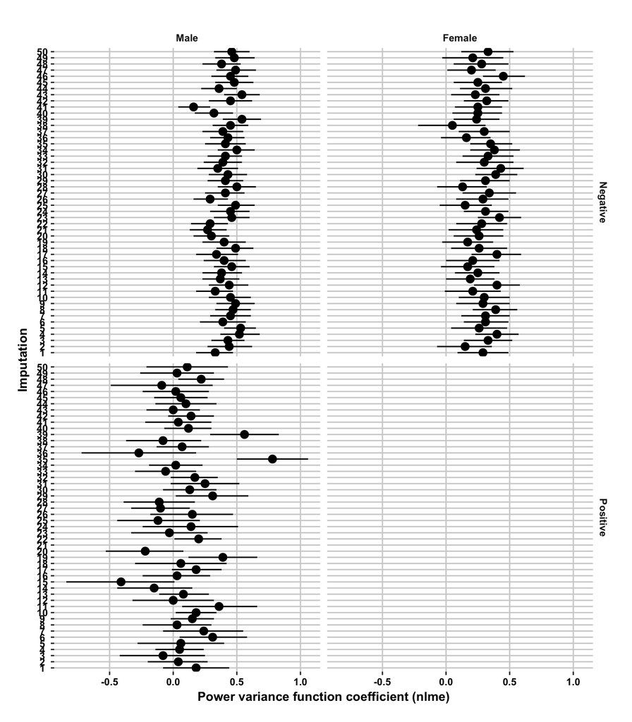

### **REPORTING MORE THAN ONE PARTNER**

[output not shown]

Categories are reported in percentages, n (%).

### **DO BRIDGEWIDTHS GROW WITH AGE?**

| **Table 1. Median and IQR for bridgewidth by age and gender in randomly selected imputed dataset** Age category | **Table 1. Median and IQR for bridgewidth by age and gender in randomly selected imputed dataset** Male n | **Table 1. Median and IQR for bridgewidth by age and gender in randomly selected imputed dataset** Male Median | **Table 1. Median and IQR for bridgewidth by age and gender in randomly selected imputed dataset** Male Q25 | **Table 1. Median and IQR for bridgewidth by age and gender in randomly selected imputed dataset** Male Q75 | **Table 1. Median and IQR for bridgewidth by age and gender in randomly selected imputed dataset** | **Table 1. Median and IQR for bridgewidth by age and gender in randomly selected imputed dataset** Female n | **Table 1. Median and IQR for bridgewidth by age and gender in randomly selected imputed dataset** Female Median | **Table 1. Median and IQR for bridgewidth by age and gender in randomly selected imputed dataset** Female Q25 | **Table 1. Median and IQR for bridgewidth by age and gender in randomly selected imputed dataset** Female Q75 |
| --- | --- | --- | --- | --- | --- | --- | --- | --- | --- |
| 15-24 | 26 | 3.5 | 2.00 | 7.00 |  | 26 | 3.5 | 1.0 | 12.0 |
| 25-34 | 28 | 5.5 | 1.00 | 8.25 |  | 33 | 3.0 | 0.0 | 6.0 |
| 35-44 | 17 | 1.0 | 1.00 | 5.00 |  | 17 | 8.0 | 2.0 | 12.0 |
| 45-54 | 18 | 4.0 | 1.25 | 10.00 |  | 9 | 0.0 | 0.0 | 12.0 |
| 55-70 | 6 | 20.0 | 10.50 | 28.75 |  | 5 | 22.0 | 22.0 | 24.0 |

IQR, Inter-quartile range Q25, Lower quartile Q75, Upper quartile

### **DOES HIV STATUS PREDICT BRIDGEWIDTH?**

Here I used generalised additive models with negative binomial regression to regress bridgewidths on HIV status of the participant before enterring our study. In these models, the participant is the unit of observation and only participants reporting more than one partner in the previous year were included. Separate models were created for men and women, as well as imputed datasets. The models adjust for age(smooth term) and race.

###### **Figure 3. Distribution of bridge widths for each imputed dataset, by sex and HIV status.**

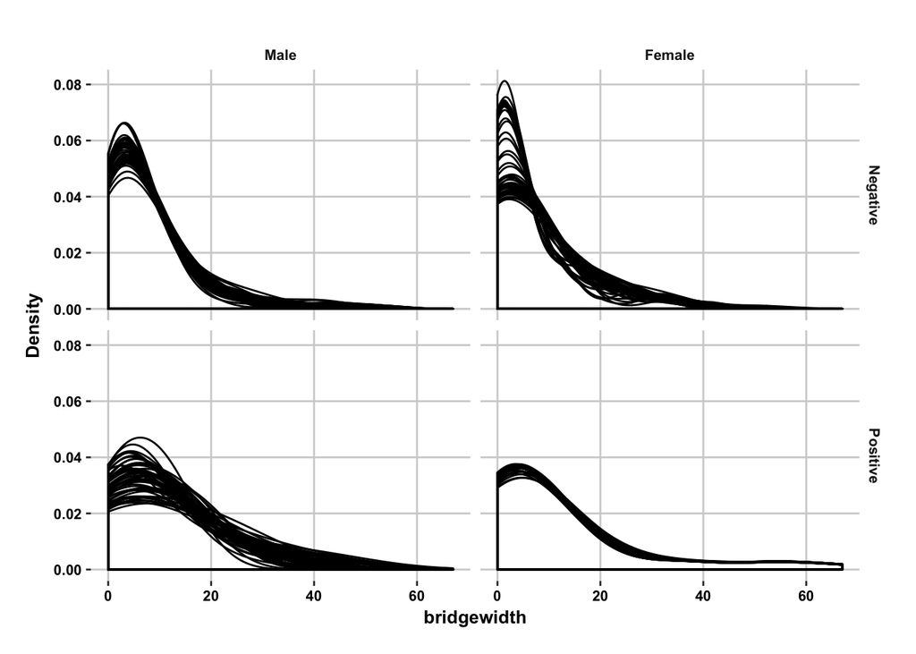

###### **Figure 4. Distribution of bridge widths for each imputed dataset, by sex and agegroup.**

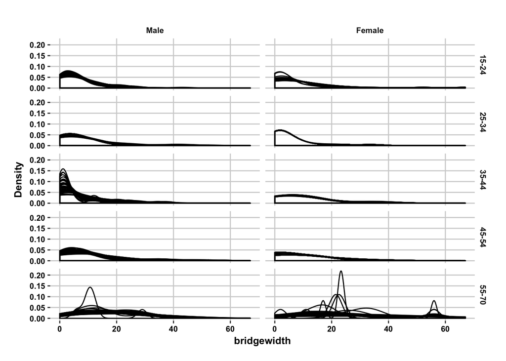

###### **Figure 5. Model coefficients for relationship between HIV and bridgewidth.**

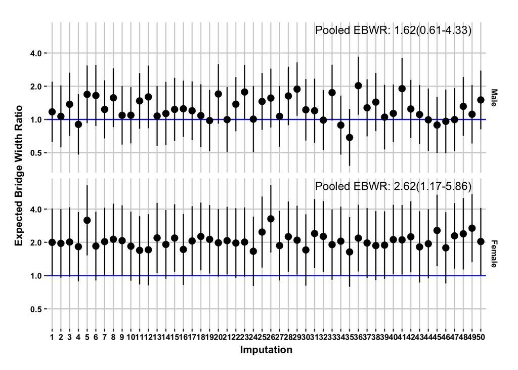

###### **Figure 6. Expected bridge widths for different values of age (smooth term), by gender.**

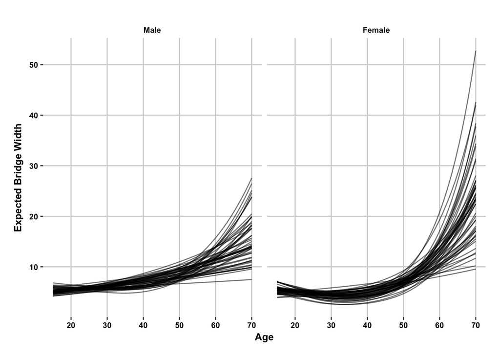